# Google Trends: Do richer countries look more to the future?

Dr. David Garcia

This exercise reproduces the findings of the article “Quantifying tthe Advantage of Looking Forward” http://www.nature.com/articles/srep00350. According to the results, the GDP per capita of countries is positively correlated to how much their population searches in Google for the next year, relative to how much they search for the previous year. This ratio is called the Future Orientation Index (FOI). So for example for the year 2017 the FOI can be calculated as: FOI = number of searches for the term “2018” / number of searches for the term “2016”.

You can find the markdown files and data for this exercise in the [corresponding Github folder](https://github.com/dgarcia-eu/SocialDataScience/tree/master/1_Introduction/018_FOIExercise)

# 1. Package installation and setup

For this task you will need to install the WDI package. The WDI package gives you access to data of the World Bank’s World Development Indicators.

**1.1 Install the WDI package**

Run the following commands in your R console to install the WDI package

```r
install.packages("WDI")
```

**1.2 Load the WDI library**

In the following chunk, load the WDI library

```r
library(WDI)
```

**1.3 Set working directory**

Check that the working directory of R Studio is the same one where you have the Markdown file. You can set it automatically with this:

```r
setwd(dirname(rstudioapi::getSourceEditorContext()$path))
```

# 2. World Bank Data

**2.1 Download WDI data**

From the WDI we need three indicators:

- Gross Domestic Product (GDP) per capita corrected by the Purchase Power Parity (PPP in current or 2005 international $, “NY.GDP.PCAP.PP.KD”)
- The amount of Internet users (per 100 people, “IT.NET.USER.ZS”)
- The total population (described as as “Population, Total”, “SP.POP.TOTL”)

In the following code chunk, download all data (including extras) for all countries in year 2014.

```r
WDIdf <- WDI(indicator = c("NY.GDP.PCAP.PP.KD", "SP.POP.TOTL", "IT.NET.USER.ZS"),
             start = 2014, end = 2014, extra = TRUE)
```

**2.2 Clean WDI data**

Some entries are not complete and some others are not countries, but regions. In the following code chunk, make sure that you only use complete rows (use the complete.cases function) and ignore groups of countries and regions by deleting rows ‘Aggregates’ on the region column.

```r
newdf <- WDIdf[complete.cases(WDIdf) & WDIdf$region != "Aggregates",]
```

**2.3 Select countries with more than 5 million internet users** In the following code chunk, calculate the value of a new column with the estimated amount of internet users in the country. Filter out countries with less than 5 Million internet users (As reported in the original article).

```r
filteredDF <- newdf[newdf$SP.POP.TOTL*newdf$IT.NET.USER.ZS/100>5000000,]
```

# 3. The Future Orientation Index in Google Trends

**3.1 Download data from Google Trends**

You can download the data from Google Trends following these steps:

- log out from your google account or set its language to English
- Go to trends.google.com and search for 2013
- add 2015 as a search term
- Select custom time rage: full year: 2014
- Set the region to “Worldwide”. You can also try with this link: https://trends.google.com/trends/explore?date=2014-01-01%202014-12-31&q=2013,2015
- Go to the map at “Compared breakdown by region” and tick on “include low search volume regions”
- On the top right menu click the download button to get a geoMap.csv file

Load the .csv file and clean its format with the following code chunk

```r
GoogleDF <-read.csv("geoMap.csv", skip=2)
names(GoogleDF) <- c("country", "G2013", "G2015")
GoogleDF$G2013 <- as.numeric(sub("%", "", GoogleDF$G2013))
GoogleDF$G2015 <- as.numeric(sub("%", "", GoogleDF$G2015))
```

**3.2 Calculate the Future Orientation Index**

In the following code chunk, make a new column in the google trends dataframe with the Future Orientation Index, which is the ratio between the search volume for 2015 and 2013 in 2014 for each country

```r
GoogleDF$FOI <- GoogleDF$G2015/GoogleDF$G2013
```

**3.2 Merge with World Bank data**

Merge the WDI and google trends data frames, using the name of the country. (Hint: use “merge” or “inner_join”)

```r
allDF <- merge(GoogleDF, filteredDF)
```

# 4. Testing the correlation between GDP and FOI

**4.1 Visualize FOI vs GDP**

Now that you have the FOI index and GPD per capita, PPP value for each country, you can make a scatter plot of FOI vs GDP

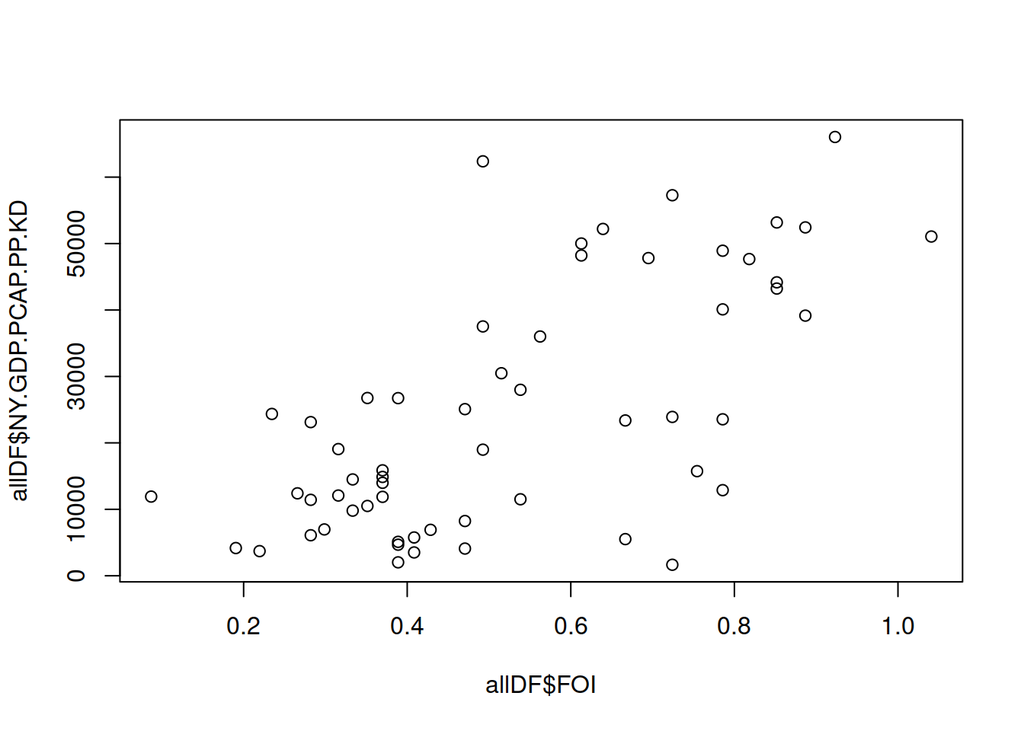

```r
plot(allDF$FOI, allDF$NY.GDP.PCAP.PP.KD)
```

**4.2 Measure Pearson’s correlation**

In the following chunk, calculate Pearson’s correlation coefficient between GDP and FOI

```r
allDF$GDP <- allDF$NY.GDP.PCAP.PP.KD
cor.test(allDF$FOI, allDF$GDP)
```

```
##
##  Pearson's product-moment correlation
##
## data:  allDF$FOI and allDF$GDP
## t = 6.6772, df = 56, p-value = 1.18e-08
## alternative hypothesis: true correlation is not equal to 0
## 95 percent confidence interval:
##  0.4921070 0.7884796
## sample estimates:
##       cor
## 0.6657765
```

**4.3 Measure correlation after shuffling**

What happens if we shuffle the data (e.g. shuffle the FOIs) and repeat the above analysis? Do you find any difference between the two plots and two Pearson’s correlation coefficients?

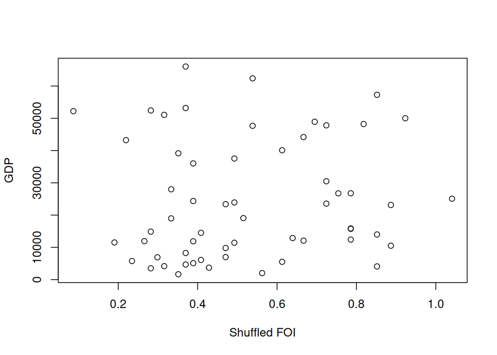

```r
shufdata <- allDF[sample(nrow(allDF)),]
plot(shufdata$FOI, allDF$GDP, xlab="Shuffled FOI", ylab="GDP")
```

```r
cor(shufdata$FOI, allDF$GDP)
```

```
## [1] 0.08584503
```

# 5. If you want to do more

- What result do you get if you use other years? What if you choose one of the earliest years in Google trends?
- How do results change if you use another threshod different to 5 Million Internet users?
- Is future orientation generating wealth? Or is it wealth enabling to look to the future?
- Is the FOI really measuring Future Orientation? Could it be something else?